# Day 3: `uwIntroStats` introduction

EPI/BIOST Bootcamp 2016

Brian D. Williamson

27 September 2016

# `uwIntroStats`

- `uwIntroStats` is an R package developed by: Scott Emerson, M.D. Ph.D.; Andrew J. Spieker, Ph.D.; myself (Brian D. Williamson); Travis Hee Wai; and Solomon Lim
- The package aims to make adopting R easier by streamlining presentation of output and making functions easier to work with

# Why `uwIntroStats`?

- Prints output in a more intuitive manner than base R
- Prints output that *we* think is important
- Wide array of functions for descriptive statistics
- Uses robust standard error estimates in all calculations

# Some useful functions

| Desired output | STATA | R (base) | R (`uwIntroStats`) |
| --- | --- | --- | --- |
| read in data (.txt file) | `infile` | `read.table()` |  |
| read in data (.csv file) | `infile` | `read.csv()` |  |
| mean | `summarize` | `summary()` | `descrip()` |
|  | `mean()` |  |  |
| std dev | `summarize` | `summary()` | `descrip()` |
|  |  | `sd()` |  |
| variance | `summarize` | `var()` | `descrip()` |
| chi-square | `tabulate` | `chisq.test()` | `tabulate()` |

# Some useful functions (continued)

| Desired output | STATA | R (base) | R (`uwIntroStats`) |
| --- | --- | --- | --- |
| boxplot | `graph box` | `boxplot()` | `bplot()` |
| histogram | `histogram` | `hist()` |  |
| density curve | `kdensity` | `plot(density())` |  |
| scatter plot | `scatter` | `plot()` | `scatter()` |
| correlation | `correlate` | `cor()` (correlation) | `correlate` |
|  |  | `cov()` (covariance) |  |
| probability | `display normprob(1)` | `1 - pnorm(1)` |  |
| (normal, z-score 1) |  |  |  |
| t-test | `ttest` | `t.test()` | `ttest()` |
| linear regression | `regress` | `lm()` | `regress()` |

# Example: `mri` data

- First, set your working directory. In RStudio, go to the pane with “Files”, “Plots”, etc. Then click “More”, then “Set as working directory”. Your console should print something like `setwd("~/Workshop2016-master/day_3_session_1")`
- Load the `mri` data:

```r
## load the package
library(uwIntroStats)
## load the data
data(mri)
```

# Example: `mri` data

- We can get descriptive statistics for the whole dataset using `descrip()`…

```r
descrip(mri)
```

```
##             N     Msng  Mean      Std Dev    Min       25%       Mdn
##     ptid:     735     0   368.0     212.3     1.000     184.5     368.0
##  mridate:     735     0   76423     31896     10192     66642     80992
##      age:     735     0   74.57     5.451     65.00     71.00     74.00
##     male:     735     0   0.4980    0.5003    0.0000    0.0000    0.0000
##     race:     735     0   1.318     0.6659    1.000     1.000     1.000
##   weight:     735     0   159.9     30.74     74.00     138.5     158.0
##   height:     735     0   165.8     9.710     139.0     158.0     165.9
##  packyrs:     735     1   19.60     27.11     0.0000    0.0000    6.500
##  yrsquit:     735     0   9.661     14.10     0.0000    0.0000    0.0000
##    alcoh:     735     0   2.109     4.852     0.0000    0.0000   0.01920
##  physact:     735     0   1.922     2.052     0.0000    0.5538    1.312
##      chf:     735     0  0.05578    0.2297    0.0000    0.0000    0.0000
##      chd:     735     0   0.3347    0.6862    0.0000    0.0000    0.0000
##   stroke:     735     0   0.2367    0.6207    0.0000    0.0000    0.0000
## diabetes:     735     0   0.1075    0.3099    0.0000    0.0000    0.0000
##  genhlth:     735     0   2.588     0.9382    1.000     2.000     3.000
##      ldl:     735    10   125.8     33.60     11.00     102.0     125.0
##      alb:     735     2   3.994     0.2690    3.200     3.800     4.000
##      crt:     735     2   1.064     0.3030    0.5000    0.9000    1.000
##      plt:     735     7   246.0     65.80     92.00     201.8     239.0
##      sbp:     735     0   131.1     19.66     78.00     118.0     130.0
##      aai:     735     9   1.103     0.1828    0.3171    1.027     1.112
##      fev:     735    10   2.207     0.6875    0.4083    1.745     2.158
##     dsst:     735    12   41.06     12.71     0.0000    32.00     40.00
##  atrophy:     735     0   35.98     12.92     5.000     27.00     35.00
##    whgrd:     735     1   2.007     1.410     0.0000    1.000     2.000
##   numinf:     735     0   0.6109    0.9895    0.0000    0.0000    0.0000
##   volinf:     735     1   3.223     17.36     0.0000    0.0000    0.0000
##  obstime:     735     0    1804     392.3     68.00      1837      1879
##    death:     735     0   0.1810    0.3852    0.0000    0.0000    0.0000
##              75%       Max
##     ptid:     551.5      735.0
##  mridate:     91392    1.232e+05
##      age:     78.00      99.00
##     male:     1.000      1.000
##     race:     1.000      4.000
##   weight:     179.0      264.0
##   height:     173.2      190.5
##  packyrs:     33.75      240.0
##  yrsquit:     18.50      56.00
##    alcoh:     1.144      35.00
##  physact:     2.513      13.81
##      chf:     0.0000     1.000
##      chd:     0.0000     2.000
##   stroke:     0.0000     2.000
## diabetes:     0.0000     1.000
##  genhlth:     3.000      5.000
##      ldl:     147.0      247.0
##      alb:     4.200      5.000
##      crt:     1.200      4.000
##      plt:     285.0      539.0
##      sbp:     142.0      210.0
##      aai:     1.207      1.728
##      fev:     2.649      4.471
##     dsst:     50.00      82.00
##  atrophy:     44.00      84.00
##    whgrd:     3.000      9.000
##   numinf:     1.000      5.000
##   volinf:    0.09420     197.0
##  obstime:      2044      2159
##    death:     0.0000     1.000
```

# Example: `mri` data

- … but this is unwieldy
- Easier to look at each variable individually, or a couple at a time (we will cover how to access single variables later)

```r
descrip(mri$age)
```

```
##            N     Msng  Mean      Std Dev    Min       25%       Mdn
## mri$age:     735     0   74.57     5.451     65.00     71.00     74.00
##             75%       Max
## mri$age:     78.00     99.00
```

- We can also look within strata

```r
descrip(mri$age, strata = mri$male)
```

```
##                    N     Msng  Mean      Std Dev    Min       25%
## mri$age:  All        735     0   74.57     5.451     65.00     71.00
## mri$age:    Str  0   369     0   74.41     5.258     65.00     71.00
## mri$age:    Str  1   366     0   74.73     5.642     66.00     71.00
##                     Mdn       75%       Max
## mri$age:  All        74.00     78.00     99.00
## mri$age:    Str  0   73.00     78.00     91.00
## mri$age:    Str  1   74.00     78.00     99.00
```

# Example: `mri` data

- Scatterplots help get a look at trends in the data

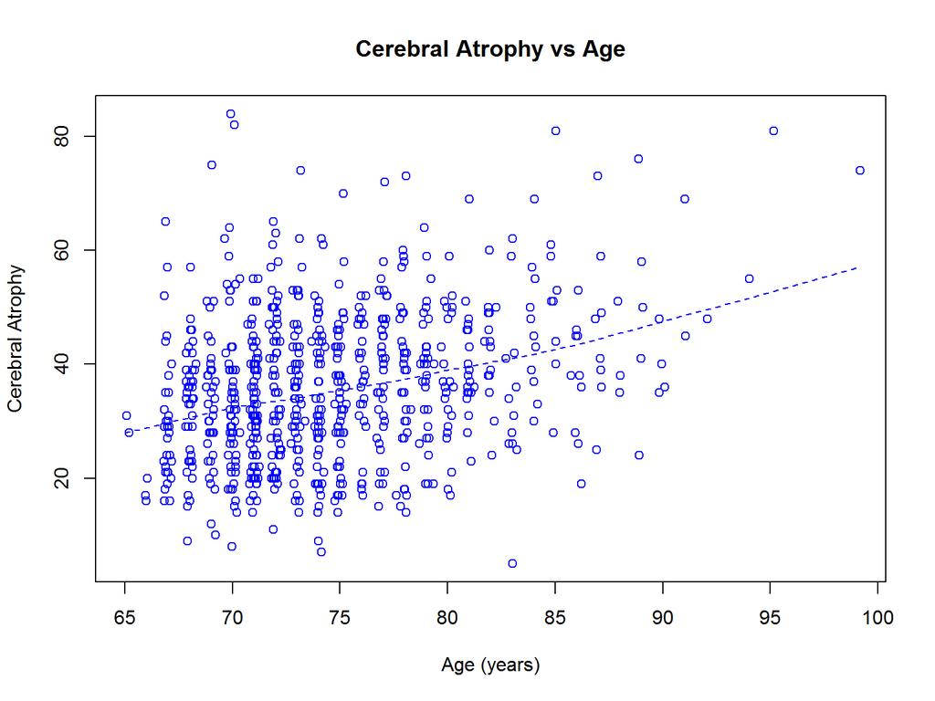

```r
scatter(mri$atrophy, mri$age, main = "Cerebral Atrophy vs Age", ylab = "Cerebral Atrophy", xlab = "Age (years)")
```

# Example: `mri` data

- Can stratify, e.g. based on sex

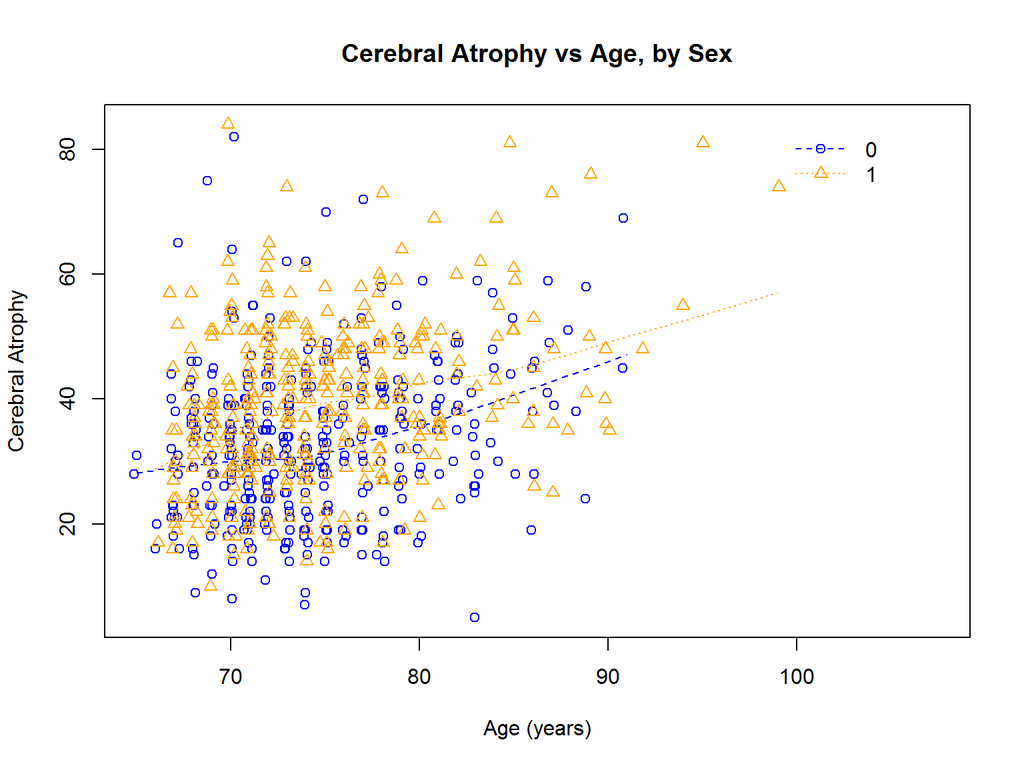

```r
scatter(mri$atrophy, mri$age, strata = mri$male, main = "Cerebral Atrophy vs Age, by Sex", ylab = "Cerebral Atrophy", xlab = "Age (years)")
```

# Summary

- `uwIntroStats` is an R package designed to make using R easier
- Provides flexible functions for descriptive statistics
- Many parallels with base R and with STATA